# UNIT13：顧客價值管理

中山大學管理學院 吳欣容、黃柏融、王欣, 2018/12/24

**【請注意】** 某些網頁互動內容只能透過[伺服器網址](https://bap.cm.nsysu.edu.tw/?page_id=1707)撥放

### 前言：從交易記錄到顧客價值

善用商業數據分析的工具和技巧，光靠一份最簡單的交易紀錄(只有顧客ID、交易日期和交易金額三個欄位)，我們就可以做一系列很深入、很有價值的顧客價值分析和行銷策略規劃，包括：

- **交易記錄分析**：
  - 敘述統計
  - 趨勢、交叉分析
  - 資料視覺化
- **顧客群組與標籤**：
  - 集群分析
  - 群組屬性分析
  - 組間流動機率
  - 顧客(個人)流動機率

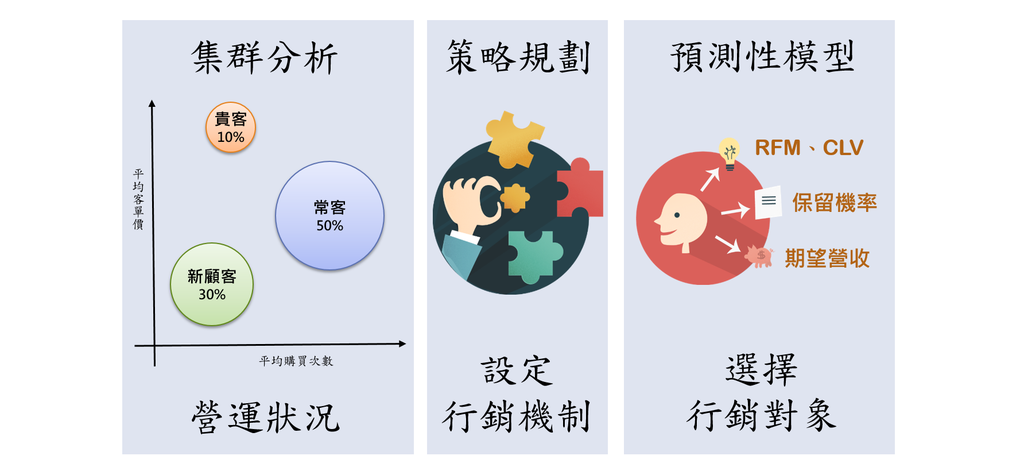

圖一、顧客價值管理的層次

從這一些分析我們可以看到公司主要的營收和獲利的重要來源，我們也可以看到這一些產生獲利的群組是不是有成長或者衰退的趨勢；據此我們可以設定行銷的重點，決定行銷的策略，和規劃行銷的工具。除了上述的敘述統計、集群分析、和資料視覺化之外，我們還可以利用這些簡單的交易紀錄：

- **建立預測性模型**，預測每一位顧客的：
  - 保留機率
  - 預期營收
  - 組間變換機率
  - 下次可能購買時間

利用這一些預測我們就可以進行全面客製化的：

- **顧客價值管理**：
  - 顧客終生價值
  - 顧客吸收策略
  - 顧客發展策略
  - 顧客保留策略
- **針對性行銷**：
  - 設計行銷方案
  - 選擇行銷方案
  - 選擇行銷對象

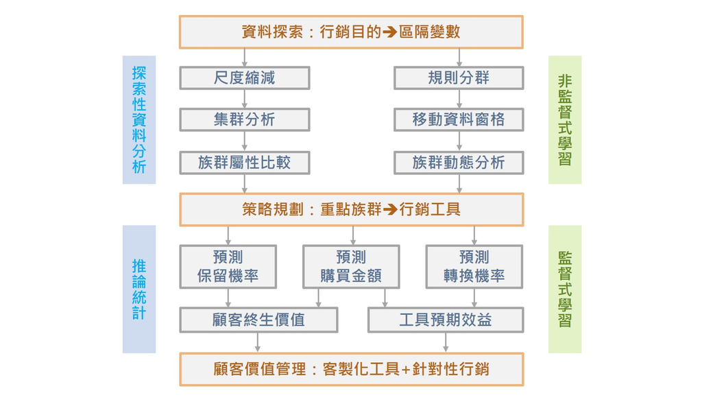

圖二、顧客價值管理流程

##### Setup

在進行分析之前，先安裝以下基本套件

```r
packages = c(
  "dplyr","ggplot2","googleVis","devtools","magrittr","caTools","ROCR","caTools")
existing = as.character(installed.packages()[,1])
for(pkg in packages[!(packages %in% existing)]) install.packages(pkg)

if(!is.element("chorddiag", existing))
  devtools::install_github("mattflor/chorddiag")
```

##### Library

```r
rm(list=ls(all=T))
options(digits=4, scipen=12)
library(dplyr)
library(ggplot2)
library(caTools)
library(ROCR)
library(googleVis)
library(chorddiag)
```

### 1. 資料整理

##### 1.1 交易資料 (X)

```r
X = read.table(
  'data/purchases.txt', header=FALSE, sep='\t', stringsAsFactors=F)
names(X) = c('cid','amount','date')
X$date = as.Date(X$date)
summary(X)                  # 交易次數 51243
```

```
##       cid             amount          date
##  Min.   :    10   Min.   :   5   Min.   :2005-01-02
##  1st Qu.: 57720   1st Qu.:  25   1st Qu.:2009-01-17
##  Median :102440   Median :  30   Median :2011-11-23
##  Mean   :108935   Mean   :  62   Mean   :2011-07-14
##  3rd Qu.:160525   3rd Qu.:  60   3rd Qu.:2013-12-29
##  Max.   :264200   Max.   :4500   Max.   :2015-12-31
```

- 在使用read.table時，R會自動將字串string辨認成factor，用stringsAsFactors = F代表，在輸入數據時，遇到字串不會將它轉換成factor，而是保留下原本的字串形式(string)。
- 例如：在這份資料中，日期(如：2005-01-02)原本是字串String，運用stringsAsFactors = F，可以將它保留字串的資料型態，也就是將它轉換為R裡面的時間日期格式。
  - cid為customer的id
  - amount為花費金額
  - date為日期
- 將整份資料以“X”命名儲存，從交易時間2005年到2015年，交易筆數51243，十年來看，這間店的資料筆數並不算太多，算是一間小雜貨店。

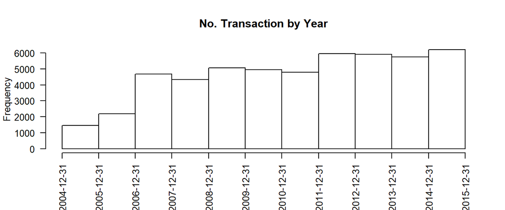

```r
par(cex=0.8)
hist(X$date, "years", las=2, freq=T, xlab="", main="No. Transaction by Year")
```

+ 透過hist可以查看各項變數資料的直方圖。 + 若要依照年份看，在code輸入year。 + 同理，也可以依照月份month排序。

```r
n_distinct(X$cid)           # 顧客數 18417
```

```
## [1] 18417
```

- n_distinct代表number of distinct，其中，括弧裡面是放vector(向量)。
- 用來辨別裡面有多少種數值，這邊放的是cid，藉此計算出有多少customer。

##### 1.2 顧客資料 (A)

```r
A = X %>%
  mutate(days = as.integer(as.Date("2016-01-01") - date)) %>%
  group_by(cid) %>% summarise(
    recent = min(days),     # 最近購買距今天數
                            # 選days裡面最小的
    freq = n(),             # 購買次數
    money = mean(amount),   # 平均購買金額
    senior = max(days),     # 第一次購買距今天數
                            # 選"天數"裡面最大的
    since = min(date)       # 第一次購買日期#看它的"日期""
  ) %>% data.frame
```

- 用group_by將顧客依照cid分組，再用mutate長出一個新欄位，稱為“days”。
- days的用意：因為整筆資料只到2015年12月底，但我們在算recency(最近購買距今天數)，要從整筆資料的最後一天，再加一天去算回來。
- 因此，距今天數的“今”，就是最後一天(2015/12/31)再加一天的(2016/1/1)。
- 將以上資料以“A”命名儲存。

##### 1.4 顧客資料摘要

```r
summary(A)
```

```
##       cid             recent          freq           money
##  Min.   :    10   Min.   :   1   Min.   : 1.00   Min.   :   5
##  1st Qu.: 81990   1st Qu.: 244   1st Qu.: 1.00   1st Qu.:  22
##  Median :136430   Median :1070   Median : 2.00   Median :  30
##  Mean   :137574   Mean   :1253   Mean   : 2.78   Mean   :  58
##  3rd Qu.:195100   3rd Qu.:2130   3rd Qu.: 3.00   3rd Qu.:  50
##  Max.   :264200   Max.   :4014   Max.   :45.00   Max.   :4500
##      senior         since
##  Min.   :   1   Min.   :2005-01-02
##  1st Qu.: 988   1st Qu.:2007-10-23
##  Median :2087   Median :2010-04-15
##  Mean   :1984   Mean   :2010-07-26
##  3rd Qu.:2992   3rd Qu.:2013-04-18
##  Max.   :4016   Max.   :2015-12-31
```

##### 1.5 變數的分布狀況

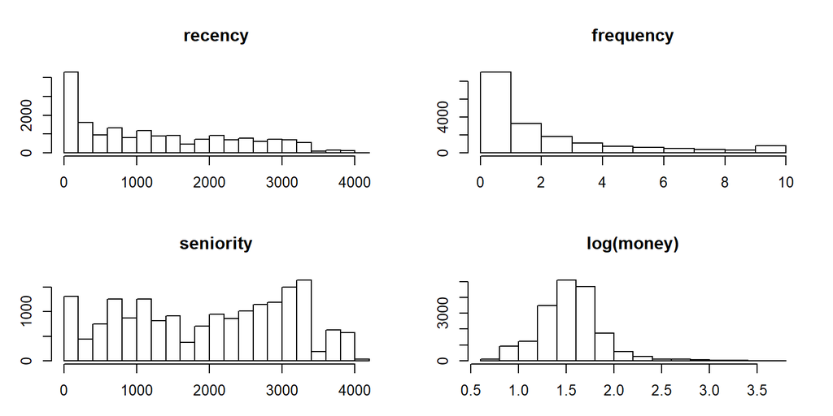

```r
p0 = par(cex=0.8, mfrow=c(2,2), mar=c(3,3,4,2))
hist(A$recent,20,main="recency",ylab="",xlab="")
hist(pmin(A$freq, 10),0:10,main="frequency",ylab="",xlab="")
hist(A$senior,20,main="seniority",ylab="",xlab="")
hist(log(A$money,10),main="log(money)",ylab="",xlab="")
```

圖形與變數解析：

- recency：最近購買距今天數。
  - 在圖形中，可以看到有一根比較長，代表有一些活躍的顧客，到最近一直在買。
  - 理論上，上一次購買時間越近的顧客是比較好的顧客，對提供即時的商品或服務最可能會有反應。
- seniority：高起來的地方，代表在當時吸收很多顧客。
- frequency：顧客在限定時間內的購買次數。
  - 我們可以說購買頻率越高的顧客，代表他的滿意度越高，忠誠度也可能越高。
  - 在R的圖形裡面，我們用pmin來看，設置一個上限，超過10的次數全部加總起來，次數它是一個離散的分布。
- log(money)：money代表消費金額，或客單價。
  - 把它取log之後，會變的比較normal，較能看出趨勢變化。
  - X軸中，1代表以10為底，1的對數，是10的意思。
  - X軸中，2代表以10為底，2的對數，是100的意思。

商務數據分析中，上述的RFM為數據分析中最好的指標，我們可以透過RFM模型了解顧客的價值以及對企業的幫助。

##### 2.1 RFM顧客分群

```r
set.seed(111)
A$grp = kmeans(scale(A[,2:4]),10)$cluster
table(A$grp)  # 族群大小
```

```
##
##    1    2    3    4    5    6    7    8    9   10
## 1073 2266 1296 2237 3207 1942 1781 2392 2096  127
```

在此我們用的是集群式分析k-means，將資料依照不同屬性將顧客做分群。 k-means分完群會把分群的向量放在“cluster”這個欄位裡面，用table(A$grp)看族群大小。

##### 2.2 顧客群組屬性

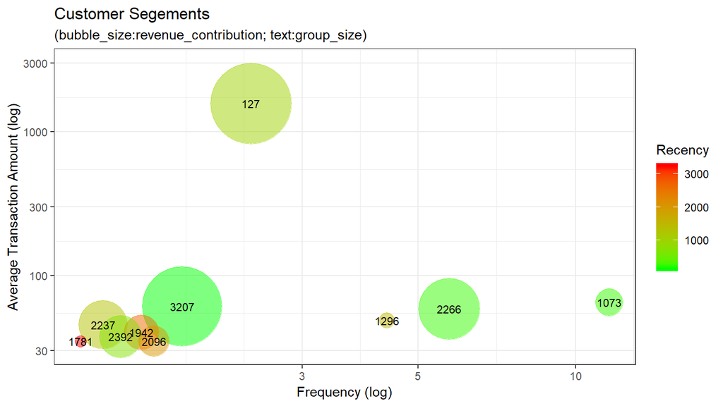

```r
group_by(A, grp) %>% summarise(
  recent=mean(recent),
  freq=mean(freq),
  money=mean(money),
  size=n() ) %>%
  mutate( revenue = size*money/1000 )  %>%
  filter(size > 1) %>%
  ggplot(aes(x=freq, y=money)) +
  geom_point(aes(size=revenue, col=recent),alpha=0.5) +
  scale_size(range=c(4,30)) +
  scale_color_gradient(low="green",high="red") +
  scale_x_log10() + scale_y_log10(limits=c(30,3000)) +
  geom_text(aes(label = size ),size=3) +
  theme_bw() + guides(size=F) +
  labs(title="Customer Segements",
       subtitle="(bubble_size:revenue_contribution; text:group_size)",
       color="Recency") +
  xlab("Frequency (log)") + ylab("Average Transaction Amount (log)")
```

圖形解析：

因此，從這些泡泡圖，我們可以知道營收來源主要來自於哪裡。藉此來看出我們的行銷重點應該放在哪一些客群上。

### 3. 規則分群

##### 3.1 顧客分群規則

```r
STS = c("N1","N2","R1","R2","S1","S2","S3")
Status = function(rx,fx,mx,sx,K) {factor(
  ifelse(sx < 2*K,
         ifelse(fx*mx > 50, "N2", "N1"),
         ifelse(rx < 2*K,
                ifelse(sx/fx < 0.75*K,"R2","R1"),
                ifelse(rx < 3*K,"S1",
                       ifelse(rx < 4*K,"S2","S3")))), STS)}
```

我們先依照三個參數(seniority, frequency, recency)把顧客分群，用ifelse條件式來將顧客區分新潛力顧客、新顧客、核心顧客、主力顧客、瞌睡顧客、半睡顧客、沉睡顧客。

- ifelse的用法是將邏輯式寫在最前面，若判斷為正確則給予第一個指定的類別名；判斷為否則給予第二個指定的類別名。
- 第一層用”第一次消費距今天數”小於兩倍”平均購買週期”來判斷是否為新顧客。(N1/N2)
- 第二層的左邊用”頻率和客單價的乘積”是否大於50來判斷是否為潛力顧客；右邊則使用”最近一次消費距今天數”是否小於兩倍”平均購買週期”來判斷是否為主力/核心顧客。(R1/R2)

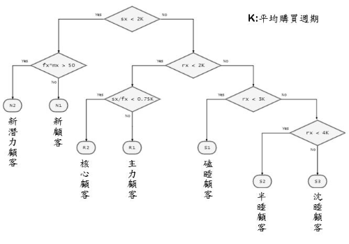

圖三、顧客分群規則

##### 3.2 平均購買週期

```r
K = as.integer(sum(A$senior[A$freq>1]) / sum(A$freq[A$freq>1])); K
```

```
## [1] 521
```

回購顧客的平均購買週期 `K = 521 days`

##### 3.3 滑動資料窗格

```r
Y = list()              # 建立一個空的LIST
for(y in 2010:2015) {   # 每年年底將顧客資料彙整成一個資料框
  D = as.Date(paste0(c(y, y-1),"-12-31")) # 當期、前期的期末日期
  Y[[paste0("Y",y)]] = X %>%        # 從交易資料做起
    filter(date <= D[1]) %>%        # 將資料切齊到期末日期
    mutate(days = 1 + as.integer(D[1] - date)) %>%   # 交易距期末天數
    group_by(cid) %>% summarise(    # 依顧客彙總 ...
      recent = min(days),           #   最後一次購買距期末天數
      freq = n(),                   #   購買次數 (至期末為止)
      money = mean(amount),         #   平均購買金額 (至期末為止)
      senior = max(days),           #   第一次購買距期末天數
      status = Status(recent,freq,money,senior,K),  # 期末狀態
      since = min(date),                      # 第一次購買日期
      y_freq = sum(date > D[2]),              # 當期購買次數
      y_revenue = sum(amount[date > D[2]])    # 當期購買金額
    ) %>% data.frame }
```

```r
head(Y$Y2015) #head可以檢視前六筆的資料
```

```
##   cid recent freq  money senior status      since y_freq y_revenue
## 1  10   3829    1  30.00   3829     S3 2005-07-08      0         0
## 2  80    343    7  71.43   3751     R1 2005-09-24      1        80
## 3  90    758   10 115.80   3783     R2 2005-08-23      0         0
## 4 120   1401    1  20.00   1401     S1 2012-03-01      0         0
## 5 130   2970    2  50.00   3710     S3 2005-11-04      0         0
## 6 160   2963    2  30.00   3577     S3 2006-03-17      0         0
```

##### 3.4 每年年底的累計顧客人數

```r
sapply(Y, nrow)  #透過sapply可以將清單的每一欄套入你指定的函數，並將結果整理以向量、矩陣、列表的形式輸出。
```

```
## Y2010 Y2011 Y2012 Y2013 Y2014 Y2015
## 10407 11674 13562 15468 16905 18417
```

##### 3.5 族群大小變化趨勢

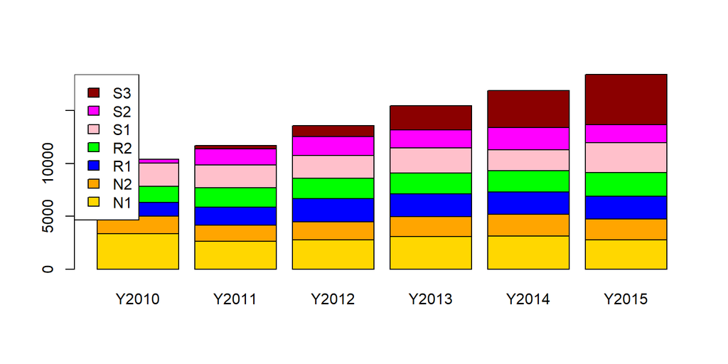

```r
cols = c("gold","orange","blue","green","pink","magenta","darkred") #指定每個族群的顏色
sapply(Y, function(df) table(df$status)) %>% barplot(col=cols)
legend("topleft",rev(STS),fill=rev(cols)) #拿來標示圖的圖例，並指定在左上角。
```

再使用直方圖繪出不同年份下的顧客分群

+要注意到的是：顧客可能在不同年份有不同的分群結果(動態)

##### 3.6 族群屬性動態分析

我們先簡單看一下每一年不同顧客分群及其各特性的平均值。

```r
CustSegments = do.call(rbind, lapply(Y, function(d) {
  group_by(d, status) %>% summarise(
    average_frequency = mean(freq),
    average_amount = mean(money),
    total_revenue = sum(y_revenue),
    total_no_orders = sum(y_freq),
    average_recency = mean(recent),
    average_seniority = mean(senior),
    group_size = n()
  )})) %>% ungroup %>%
  mutate(year=rep(2010:2015, each=7)) %>% data.frame
head(CustSegments)
```

```
##   status average_frequency average_amount total_revenue total_no_orders
## 1     N1             1.154          26.96         41046            1500
## 2     N2             2.263          96.00        121034            1416
## 3     R1             2.674          43.25         19407             435
## 4     R2             5.406          60.31        108631            1588
## 5     S1             1.267          44.61             0               0
## 6     S2             1.167          60.65             0               0
##   average_recency average_seniority group_size year
## 1           449.2             507.1       3330 2010
## 2           241.2             629.9       1655 2010
## 3           492.4            1470.0       1298 2010
## 4           157.1            1547.3       1547 2010
## 5          1289.3            1373.1       2203 2010
## 6          1889.7            1922.4        360 2010
```

**【請注意】**

- 互動式泡泡圖不會出現在你Knit出來的網頁裡面
- 但你可以在RStudio執行下一個程式區塊，互動式泡泡圖會直接投放到你的瀏覽器上面
- 你還需要打開Flash選項，才能在瀏覽器裡操作互動式泡泡圖
- 想要直接在網頁上操作互動式泡泡圖，請參考[伺服器網址](https://bap.cm.nsysu.edu.tw/?page_id=1707)

```r
# op = options(gvis.plot.tag='chart')
m1 = gvisMotionChart(
  CustSegments, "status", "year",
  options=list(width=720, height=480) )
plot(m1)
```

利用動態泡泡圖，我們可追蹤各顧客族群的中、長期變化趨勢，如下圖所示， 四個主要顧客族群在過去幾年間變化的趨勢都不一樣。

[figure not shown]

##### 3.7 族群屬性動態分析

```r
df = merge(Y$Y2014[,c(1,6)], Y$Y2015[,c(1,6)],
           by="cid", all.x=T)
tx = table(df$status.x, df$status.y) %>%
  as.data.frame.matrix() %>% as.matrix()
tx    # 流量矩陣(選擇2014和2015兩年的分群結果做流量分析)
```

```
##      N1   N2   R1   R2  S1   S2   S3
## N1 1705  381  144   45 831    0    0
## N2    0 1131  267  430 263    0    0
## R1    0    0 1240   43 819    0    0
## R2    0    0  199 1742  75    0    0
## S1    0    0  115    3 819 1026    0
## S2    0    0   78    1   0  692 1339
## S3    0    0   97    0   0    0 3420
```

我們可以想像今年被判斷是主力顧客的顧客明年可能會變成瞌睡顧客，所以把每兩年的顧客分群結果做流量矩陣來看出數量上的變化

```r
tx %>% prop.table(1) %>% round(3)   # 流量矩陣(%)
```

```
##       N1    N2    R1    R2    S1    S2    S3
## N1 0.549 0.123 0.046 0.014 0.268 0.000 0.000
## N2 0.000 0.541 0.128 0.206 0.126 0.000 0.000
## R1 0.000 0.000 0.590 0.020 0.390 0.000 0.000
## R2 0.000 0.000 0.099 0.864 0.037 0.000 0.000
## S1 0.000 0.000 0.059 0.002 0.417 0.523 0.000
## S2 0.000 0.000 0.037 0.000 0.000 0.328 0.635
## S3 0.000 0.000 0.028 0.000 0.000 0.000 0.972
```

或者是看出百分比的變化。

##### 3.8 互動式流量分析

```r
chorddiag(tx, groupColors=cols)
```

[interactive chart not shown]

利用chorddiag來將剛剛流量變化的結果視覺化。